# Hw2_Question1

## Homework 2

## Network Analytics

### Question 1

By Group A3:

Jiaqi Chen, Yuxi Fu, Jiaxuan Lyu, Maria Tsotalou, Qian Zhang

Initially we will load the data and create the network. Afterwards we will present the report.

```python
# Importing Modules
import networkx as nx

import pandas as pd
import numpy as np

from scipy import linalg
from scipy.sparse.linalg import eigsh

import matplotlib.pyplot as plt

import operator
import sys

import numbers
```

```python
# Loading dataset
excelfile = 'HW2_who_talks_to_whom.xlsx'

sent = pd.read_excel(excelfile, sheet_name = 'Sent')
sent = sent.set_index('Nodes')
sent_list = sent.stack().reset_index()

sent_list.columns = ['Sender','Receiver','Messages']

# Remove self loops
sent_list.columns = ['Sender','Receiver','Messages']
sent_list = sent_list.loc[sent_list['Sender'] != sent_list['Receiver']].copy()

sent_list["Messages"]  = sent_list["Messages"].astype(int)
```

Note: The two sheets on the excel file, namely "Sent"and "Received", are not fully aligned. We have chosen to proceed with the Sent sheet, since ideally the two sheets would give us the same information from a different perspective.

```python
# Creating a directed graph
G = nx.DiGraph()
for (sender, receiver, msg) in sent_list.values:
    if (isinstance(msg, numbers.Number)):
        G.add_edge(sender, receiver, weight=msg)
```

```python
# node size based on in/out degrees
node_size_in = []
for (node, val) in G.in_degree():
    node_size_in.append(val*15)

node_size_out = []
for (node, val) in G.out_degree():
    node_size_out.append(val*15)
```

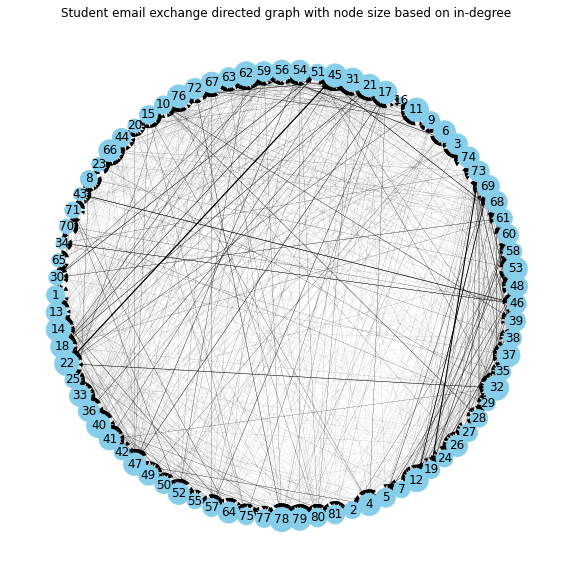

```python
#plot the graph
edge_width = []
for key, value in nx.get_edge_attributes(G, 'weight').items():
    edge_width.append(abs(value * 0.01))

plt.subplots(figsize=(10,10))
nx.draw_shell(G, with_labels = True, node_color='skyblue', node_size=node_size_in, width = edge_width)
fig = plt.gcf()
plt.title('Student email exchange directed graph with node size based on in-degree')
plt.show()
```

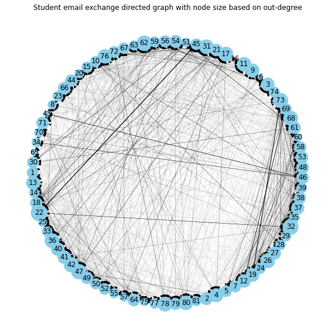

```python
#plot the graph
edge_width = []
for key, value in nx.get_edge_attributes(G, 'weight').items():
    edge_width.append(abs(value * 0.01))

plt.subplots(figsize=(10,10))
nx.draw_shell(G, with_labels = True, node_color='skyblue', node_size=node_size_out, width = edge_width)
fig = plt.gcf()
plt.title('Student email exchange directed graph with node size based on out-degree')
plt.show()
```

#### Centrality measures functions

```python
# Degree Centrality

# In-Degree Centrality
def get_top5_indegree_centrality():
    in_deg_cent = nx.algorithms.in_degree_centrality(G)
    in_deg_cent_rounded = {key : round(in_deg_cent[key], 4) for key in in_deg_cent}
    print('Top 5 Students with highest in-degree centrality:')
    for key, value in sorted(in_deg_cent_rounded.items(), key=lambda item: item[1], reverse=True)[:5]:
        print("%d: %s" % (key, value))

# Out-Degree Centrality

def get_top5_outdegree_centrality():
    out_deg_cent= nx.algorithms.out_degree_centrality(G)
    out_deg_cent_rounded = {key : round(out_deg_cent[key], 4) for key in out_deg_cent}
    print('Top 5 Students with highest out-degree centrality:')
    for key, value in sorted(out_deg_cent_rounded.items(), key=lambda item: item[1], reverse=True)[:5]:
        print("%d: %s" % (key, value))

# Betweeness Centrality
def get_betweeness_centrality():
    bet_cent = nx.algorithms.centrality.betweenness_centrality(G)
    bet_cent_rounded = {key : round(bet_cent[key], 4) for key in bet_cent}
    print('Top 5 Students with highest betweeness centrality:')
    for key, value in sorted(bet_cent_rounded.items(), key=lambda item: item[1], reverse=True)[:5]:
        print("%d: %s" % (key, value))

# Closeness Centrality
def get_closeness_centrality():
    close_cent = nx.algorithms.centrality.closeness_centrality(G)
    close_cent_rounded = {key : round(close_cent[key], 4) for key in close_cent}
    print('Top 5 Students with highest closeness centrality:')
    for key, value in sorted(close_cent_rounded.items(), key=lambda item: item[1], reverse=True)[:5]:
        print("%d: %s" % (key, value))


# Eigenvector Centrality
def get_eigenvector_centrality():
    eigenvector_cent=nx.eigenvector_centrality_numpy(G)
    eigenvector_cent_rounded = {key : round(eigenvector_cent[key], 4) for key in eigenvector_cent}
    print('Top 5 Students with highest eigenvector centrality:')
    for key, value in sorted(eigenvector_cent_rounded.items(), key=lambda item: item[1], reverse=True)[:5]:
        print("%d: %s" % (key, value))

# Clustering coefficient
def get_clustering_coef():
    clustering_graph = nx.average_clustering(G)
    print("Clustering of each node = {:.4f}".format(clustering_graph))
```

## Organizational network analysis:

In this organizational network analysis report, the leaders and key opinion makers in the student cohort would be identified.

First, we calculate the clustering coefficient of the graph.

```python
get_clustering_coef()
```

```
Clustering of each node = 0.5329
```

The coefficient is relatively high. That fact suggests that the cohort is well connected and tightly knitted.

In order to identify the 'central' students who are the leaders in the cohort, several centrality measures (both local and global) are calculated for each student. The first centrality measure calculated is the degree centrality, in particular in-degree centrality and out-degree centrality. The in-degree centrality measures the number of emails each student received (normalised).

```python
get_top5_indegree_centrality()
```

```
Top 5 Students with highest in-degree centrality:
32: 0.5
14: 0.4875
22: 0.475
40: 0.475
78: 0.475
```

This measure is highest for student '32' , '14' and '22. This suggests that these students are popular in the cohort as they received the highest number of emails.

Similarly, the out-degree centrality measures the number of emails sent by each student and this is also highest for '22', '32' and '47'.

```python
get_top5_outdegree_centrality()
```

```
Top 5 Students with highest out-degree centrality:
22: 0.6125
32: 0.55
47: 0.525
62: 0.525
42: 0.5125
```

Another centrality measure calculated is betweenness centrality which measures the sum of the fraction of all-pairs shortest paths that pass through student 'x'. Betweenness centrality is highest for student '22' and '32'. This suggest they are the more central students in the cohort as they are more likely to build a bridge between other students. Moreover, closeness centrality is the reciprocal of the average shortest path distance a student over all n-1 reachable students. Closeness centrality is the highest for stduent '14', '32' and '40', this means it is easier for other students to reach them in the email network.

```python
get_betweeness_centrality()
```

```
Top 5 Students with highest betweeness centrality:
32: 0.0343
22: 0.03
62: 0.0239
26: 0.022
78: 0.021
```

```python
 get_closeness_centrality()
```

```
Top 5 Students with highest closeness centrality:
14: 0.6556
32: 0.6556
40: 0.6501
53: 0.6501
22: 0.6447
```

With regards to the global centrality measures, the eigenvector centrality of each student is calculated, which computes the centrality for a student based on the centrality of its neighbors. Once again from our calculations, the eigenvector centrality is highest for student '22', '78' and '40'. This shows that these three students are well connected to other 'important' students in the cohort.

```python
get_eigenvector_centrality()
```

```
Top 5 Students with highest eigenvector centrality:
22: 0.1781
78: 0.1779
40: 0.1753
31: 0.1742
14: 0.1731
```

Thus, from the analysis there are indications that the student '22', and '32' are definitely 'central' students in the cohort.